# Análise Ambiental

Bacia Hidrográfica como  
Unidade de Análise Ambiental

Luiz Diego Vidal Santos

## Visão Geral da Aula

### Tópicos

- 1 Microbacias e divisores topográficos
- 2 Rede de drenagem
- 3 Áreas ripárias
- 4 Conectividade hidrossedimentológica
- 5 Processos erosivos
- 6 Escoamento superficial
- 7 Uso da terra

**Objetivo da Aula**

Adotar a bacia hidrográfica como unidade integradora de análise, articulando topografia, drenagem, áreas ripárias e processos hidrossedimentológicos.

# 1 - BACIA HIDROGRÁFICA COMO UNIDADE

## Por que a bacia?

### Justificativas

- É uma **unidade física natural**, delimitada por divisores topográficos.
- Integra **clima, relevo, solo, vegetação, uso da terra** num sistema convergente.
- A **água** funciona como integradora física de todos os processos.
- É a **unidade legal de gestão** de recursos hídricos no Brasil (Lei 9.433/1997).

### Recortes operacionais

| Recorte | Característica | Uso típico |
| --- | --- | --- |
| **Macrobacia** | Grandes rios federais | Políticas regionais |
| **Bacia** | Comitê de Bacia, Plano de Bacia | Outorga, cobrança |
| **Sub-bacia** | Recorte de gestão municipal | Plano Diretor, ETA/ETE |
| **Microbacia** | < 100 km² | Manejo conservacionista, escala local |

**Marco legal brasileiro**

- **Lei 9.433/1997** (Política Nacional de Recursos Hídricos): institui a bacia como **unidade de planejamento**.
- **Lei 12.651/2012** (Código Florestal): APPs de rios e nascentes.
- **ANA** + **órgãos estaduais** + **Comitês de Bacia**: governança tripartite.

> A bacia articula a **Análise Ambiental** com a **gestão de recursos hídricos**.

## Topografia e rede de drenagem

### Caracterização morfométrica

| Índice | Significado |
| --- | --- |
| **Área (A)** e **Perímetro (P)** | Magnitude e forma da bacia |
| **Kc (compacidade)** | $K_c = 0{,}28 \cdot P / \sqrt{A}$; próximo de 1 = propensa a cheias |
| **Dd (densidade de drenagem)** | $D_d = L_t / A$ (km/km²); reflete permeabilidade |
| **Ordem (Strahler)** e **Declividade** | Hierarquia da rede e energia do relevo |

**Fluxo no SIG (QGIS/GRASS)**

MDE → Preenchimento → Direção/acúmulo de fluxo → Extração de canais → Delimitação da bacia → Cálculo morfométrico.

> Produtos: carta hipsométrica, declividade e rede de drenagem hierarquizada.

# 2 - PROCESSOS HIDROSSEDIMENTOLÓGICOS

## Conectividade e uso da terra

### Conectividade hidrossedimentológica

- Capacidade do sistema em **transferir água e sedimentos** das vertentes para a rede.
- Conectividade **estrutural** (topografia, cobertura, barreiras) + **funcional** (eventos chuvosos, umidade ant.).
- Índice de Conectividade (IC - Borselli *et al.*, 2008) mapeia em SIG zonas-fonte e zonas-sumidouro.

### Variáveis-chave

| Variável | Efeito sobre o escoamento |
| --- | --- |
| Cobertura vegetal | ↑ cobertura → ↓ escoamento, ↑ infiltração |
| Compactação | ↑ compactação → ↑ escoamento, ↓ infiltração |
| Selamento urbano | ↑ imperm. → ↑ vazões de pico, ↓ recarga |
| Declividade | ↑ declividade → ↑ velocidade, ↑ erosão |
| Mata ciliária | Filtra sedimentos, estabiliza margens |

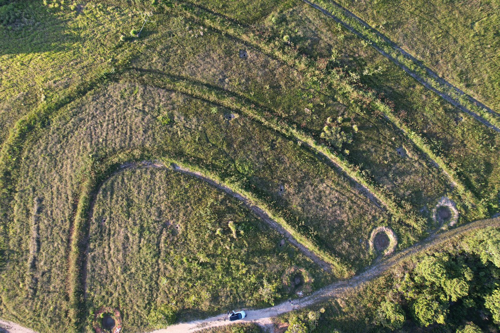

**Áreas ripárias**

- Interface terra-água: **APP** legal (30-500 m).
- Funções:
  - Filtragem de sedimentos e nutrientes
  - Estabilização de margens
  - Corredor ecológico
  - Sombreamento e regulação térmica do curso d’água
- Diagnóstico via SR (NDVI, MapBiomas) + buffer em SIG.

### Indicadores de pressão

- Taxa de cobertura nativa por sub-bacia
- % de APP em conflito de uso
- Densidade de feições erosivas
- Carga difusa estimada (MUSLE / SWAT)
- Concentração de sólidos suspensos (qualidade da água)

## Produto da aula: diagnóstico hidrológico

### Roteiro prático (QGIS)

1. Delimitar bacia/sub-bacias a partir do MDE e calcular parâmetros morfométricos.
2. Sobrepor com **MapBiomas** (uso da terra) e **CAR** (APP, RL).
3. Mapear APPs em conflito de uso e calcular cobertura nativa por sub-bacia.
4. Hierarquizar sub-bacias por **pressão ambiental** (tabela-síntese de fragilidade).

**Bases gratuitas**

| Base | Conteúdo |
| --- | --- |
| ANA/SNIRH | Séries fluviométricas e pluviométricas |
| INMET | Estações meteorológicas |
| EMBRAPA Hidrogeo | Dados hidrogeológicos |
| INPE / TOPODATA | MDE SRTM - 30 m |
| ALOS PALSAR | DEM 12,5 m (NASA Earthdata) |
| MapBiomas | Uso/cobertura anual |
| SICAR | CAR - APP/RL declaradas |

# Referências

## Bibliografia da aula

- BOTELHO, R. G. M.; SILVA, A. S. Bacia hidrográfica e qualidade ambiental. In: VITTE, A. C.; GUERRA, A. J. T. (org.). **Reflexões sobre a geografia física no Brasil**. Rio de Janeiro: Bertrand Brasil, 2004.
- CHRISTOFOLETTI, A. **Geomorfologia fluvial**. São Paulo: Edgard Blücher, 1981.
- GUERRA, A. J. T.; CUNHA, S. B. (org.). **Geomorfologia e meio ambiente**. Rio de Janeiro: Bertrand Brasil, 1996.